# PLM Course Project

Chad

February 7, 2019

## Executive Summary

One thing that people regularly do is quantify how much of a particular activity they do, but they rarely quantify how well they do it. The goal of my project was to predict the manner in which six participants did the weight lifting exercises. Participants were asked to perform one set of 10 repetitions of the Unilateral Dumbbell Biceps Curl in five different fashions: exactly according to the specification (Class A), throwing the elbows to the front (Class B), lifting the dumbbell only halfway (Class C), lowering the dumbbell only halfway (Class D) and throwing the hips to the front (Class E). Class A corresponds to the specified execution of the exercise, while the other 4 classes correspond to common mistakes.

```r
# load required libraries
library(ggplot2); library(caret); library(randomForest);
# download data files
#download.file("https://d396qusza40orc.cloudfront.net/predmachlearn/pml-training.csv",getwd())
#download.file("https://d396qusza40orc.cloudfront.net/predmachlearn/pml-testing.csv", getwd())

# load data files into memory
training.orig <- read.csv(url("https://d396qusza40orc.cloudfront.net/predmachlearn/pml-training.csv"))
testing <- read.csv(url("https://d396qusza40orc.cloudfront.net/predmachlearn/pml-testing.csv"))

# modify data to remove unnecessary variables
training.mod <- training.orig[,-c(1:7,12:36,50:59,69:83,87:101,103:112,125:139,141:150)]
```

## Overview

Using devices such as Jawbone Up, Nike FuelBand, and Fitbit it is now possible to collect a large amount of data about personal activity relatively inexpensively. These type of devices are part of the quantified self movement – a group of enthusiasts who take measurements about themselves regularly to improve their health, to find patterns in their behavior, or because they are tech geeks. One thing that people regularly do is quantify how much of a particular activity they do, but they rarely quantify how well they do it. In this project, your goal will be to use data from accelerometers on the belt, forearm, arm, and dumbell of 6 participants. They were asked to perform barbell lifts correctly and incorrectly in 5 different ways. More information is available from the website here: http://web.archive.org/web/20161224072740/http:/groupware.les.inf.puc-rio.br/har (see the section on the Weight Lifting Exercise Dataset).

## Model Building

For this project, we are looking to classify the fashion in which the exercise was performed (i.e. Classes A through E). We tested (“quized”) the following the following models: multinomial logistic regression, classification and regression tree, and random forest.

### Cross Validation

We used simple partition for cross validation to separate the training set into a training and quiz set. We will use the test set once we have selected our model.

```r
set.seed(1928)

# create train and quiz sets for cross validation
inTrain <- createDataPartition(y=training.mod$classe, p=0.75, list=FALSE)
training <- training.mod[inTrain, ]
quizing <- training.mod[-inTrain, ]
```

### Multinomial Logistic Regression

```r
# build model
multinomModel <- train(classe ~ ., method = "multinom", data = training, trace = FALSE)

# get predictions on quizing set
multinomPred <- predict(multinomModel, newdata = quizing)
```

### Classification and Regression Trees

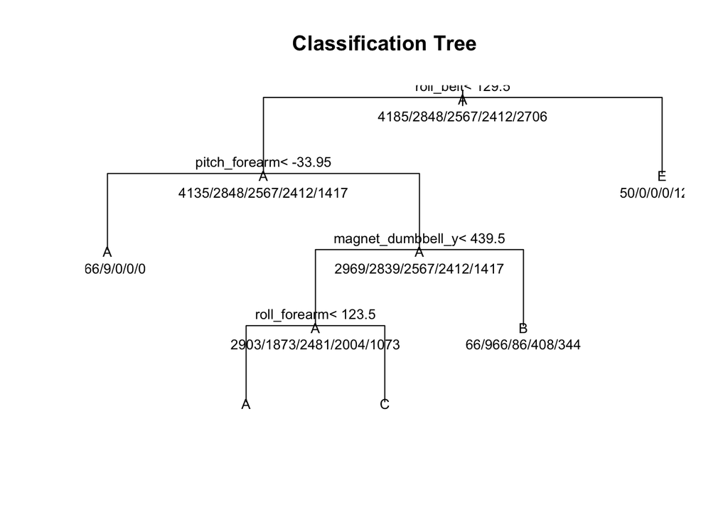

```r
# build model
rpartModel <- train(classe ~ ., method = "rpart", data=training)

# get predictions on quizing set
rpartPred <- predict(rpartModel, newdata = quizing)

# plot model
plot(rpartModel$finalModel, uniform = TRUE, main="Classification Tree")
text(rpartModel$finalModel, use.n = TRUE, all = TRUE, cex = 0.8)
```

### Random Forest

```r
# build model
# note: we set the number of trees to 32 to reduce proceessing time, resulting in a slight decrease in accuracy.
rfModel <- train(classe ~ ., method = "rf", data=training, ntree = 32)

# get predictions on quizing set
rfPred <- predict(rfModel, newdata = quizing)
```

## Model Testing

```r
testPred <- predict(rfModel, newdata = testing)
print(testPred)
```

```
##  [1] B A B A A E D B A A B C B A E E A B B B
## Levels: A B C D E
```